# **研究對象介紹**

## **1. ODI(The Open Data Institute)**

[ODI](https://theodi.org/) 為非營利國際組織，其目標在於協助企業及政府打造開放、可信任的資料生態系統。 ODI 創立於 2012 年 ，總部設立於英國倫敦，共同創辦人為 [Sir Tim Berners-Lee](https://twitter.com/timberners_lee) 及 [Sir Nigel Shadbolt](https://twitter.com/nigel_shadbolt)。

## **2. OGP(The Open Government Partnership)**

[OGP](https://www.opengovpartnership.org/) 是由多國政府發起的倡議行動，其目標在於透過參與國及參與公民組織相互監督的方式，促成更開放的國家治理，其中的行動包含減少貪腐、公開政府資訊、協助公有財治理等。該倡議行動於 2011 年由多國政府及公民團體發起，參與國須定期提供自我評量報告(Self-Assessment Reports)，最後由第三方單位對參與會員國提出的報告進行監督，評量各國在減少貪腐、公開政府、公有財治理等議題上的年度進展。

# **研究架構**

本研究共可分為兩部分，分別是「跟隨網絡」(Following)與「提及網絡」(Mention)的研究，下圖是研究流程概覽。

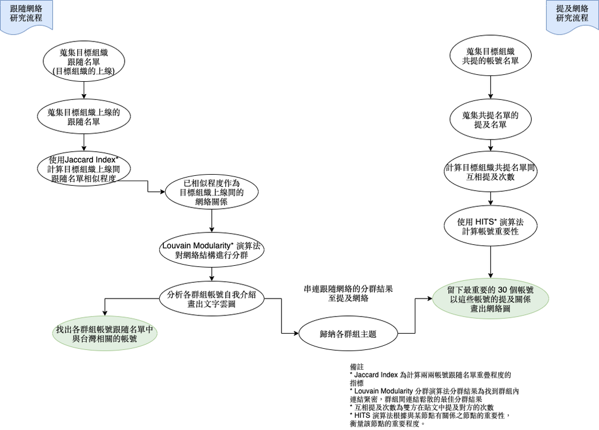

## **1. 跟隨網絡**

跟隨網絡的部分，本研究首先蒐集目標組織的跟隨名單(以下簡稱為目標組織的上線)，接著再蒐集這些上線帳號的跟隨名單，並計算兩個上線帳號的相似程度。相似程度的衡量我們使用的是 Jaccard Index，若以數學式表達帳號 A 和帳號 B 跟隨名單的相似程度，可以用文氏圖表示為：

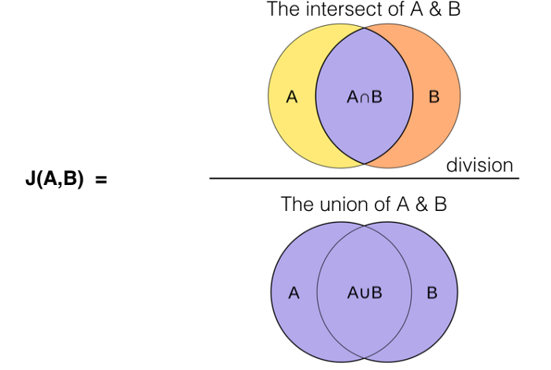

[Jaccard Index 示意圖](https://medium.com/data-science-bootcamp/understand-jaccard-index-jaccard-similarity-in-minutes-25a703fbf9d7)

Jaccard Index 的意義在於衡量兩個帳號跟隨名單的重疊程度，該數值介於 0 到 1 之間，數值越大代表兩個帳號跟隨名單的重疊程度越高。Stewart 等人(2017)同樣使用 Jaccard Index 計算兩個帳號的相似程度，差別在於其研究的假設是透過兩個帳號的跟隨者(Follower)名單重疊性，判斷帳號間是否共享類似的觀眾，本研究則是假設透過兩個帳號關注的帳號，也就是其跟隨名單的重疊程度，可以衡量兩個帳號關注的議題是否類似。

計算完目標組織兩個上線彼此的相似程度後，為避免網絡圖中有過多的雜訊，我們定義兩個帳號的相似關係必須建立在相似度高於一定程度上(高於 99.9 百分位數)，至此我們便得到一無向*的網絡關係圖。

有了網絡資料後，我們使用 Blondel 等人(2008)提出的 Louvain modularity 演算法為網絡進行分群，該演算法的目標在於找到最適切的分組，使得組內節點間的連結緊密，且組間節點的連結鬆散。分好群後，我們留下節點數最多的數群帳號*。由於我們希望找到每個群集內獨特的議題，該議題可能會有與之對應的專屬關鍵字，因此我們透過 DF-IDF(Document Frequency Inverse Document Frequency) 演算法找出各群集帳號間帳號自述的關鍵字，該演算法的特色在於能夠找出一組字詞，該字詞不會出現在多個組別中，但會頻繁出現在特定組別內。此演算法可以幫助我們得到各個組別的重要字詞排行，接著將這些字詞以文字雲的方式視覺化，由筆者歸納文字雲得到與各組別相關的議題名稱，最後在網絡圖中加入各組帳號跟隨台灣相關帳號*的關係。

總結來說，跟隨網絡研究流程可簡化為以下五步驟：

1. 蒐集目標組織上線名單
2. 利用 Jaccard Index 計算上線帳號間的相似程度
3. 篩選相似程度高於 99.9 百分位數的關係，並以 Louvain modularity 演算法對此關係的網絡進行分群
4. 篩選節點數最多的群組，針對各群組的帳號自述進行資訊檢索，摘要出個群組重要字詞，並以人工的方式為個群組命名
5. 繪製跟隨關係網絡圖，並在圖上加上各上線帳號跟隨的台灣相關帳號

## **2. 提及網絡**

*某 A 帳號若提及 B 帳號 5 次，但 B 帳號提及 A 帳號 0 次，則兩者關係僅計算為 A -> B ，權重為 5 。*  
*若 A 帳號提及 C 帳號 5 次，且 C 帳號提及 A 帳號 4 次，則計算為 A -> C ，權重為 5 ， C -> A ，權重為 4。*

此演算法計算收斂後，我們就能夠得到在提及網絡裡「中心」數值最高的節點。接著我們進一步篩選「中心」數值前三十高的帳號作為前三十重要的帳號，並在前述有向網絡中留下與這三十個帳號有提及關係的帳號，最後再去搜尋剩餘在網絡中的所有帳號的提及名單中，與台灣相關的帳號。

簡單來說，至今執行的步驟及其目的依序是：

1. 先從目標組織認為有同場演出的帳號中篩選出第一批目標名單
2. 為了確認目標名單彼此的關係，我們計算名單內兩個帳號彼此提及的狀況
3. 利用 HITS 演算法從網絡中篩選出重要帳號，以及該重要帳號衍伸的提及帳號(此步驟留下的帳號可視為對於目標組織來說相對重要的帳號)
4. 從上述步驟找到的重要帳號的提及名單中，找出與台灣相關的帳號

研究最後將篩選過的結果整理成一異質性的網絡，該網絡有兩種關係，一種是提及台灣帳號的關係，該關係為單向的，關係權重為提及台灣帳號的次數，另一種關係是透過 HITS 演算法篩選重要帳號而衍伸的關係，該類別關係為無向的，關係權重則是參考 Conover 等人(2011)的研究，將兩個帳號提及次數加總，作為兩帳號的關係權重。

#### * 無向網絡的意義在於不同方向的關係所代表的意義相同，舉例來說若定義帳號 A 和帳號 B 兩帳號的關係為兩個帳號互相提及次數加總，則該關係為無向的，因為 A -> B 和 B -> A 數值相同。

#### * 台灣相關帳號定義為該帳號自我介紹中有出現 Taiwan 、 Taipei ，或帳號設定的所在地位於 Taiwan 、 Taipei 。

#### * 由於篩選群數並沒有標準答案，本研究篩選的原則是各群的數量不能落差過大，且各群組在網絡視覺化後不應該有太多重疊的部分，本研究針對 ODI 跟隨網絡分群暫時以五群為主，其他分群結果可參考附錄提供的網絡圖。

#### * 發布推文的定義為該則推文作者為該目標組織，且該則貼文不屬於回推(Retweet)。

#### * 有向網絡的意義在於不同方向的關係所代表的意義不同。

#### 1. Blondel, V. D., Guillaume, J. L., Lambiotte, R., & Lefebvre, E. (2008). Fast unfolding of communities in large networks. Journal of statistical mechanics: theory and experiment, 2008(10), P10008.

#### 2. Conover, M. D., Gonçalves, B., Ratkiewicz, J., Flammini, A., & Menczer, F. (2011, October). Predicting the political alignment of twitter users. In 2011 IEEE third international conference on privacy, security, risk and trust and 2011 IEEE third international conference on social computing (pp. 192-199). IEEE.

#### 3. Kleinberg, J. M., Newman, M., Barabási, A. L., & Watts, D. J. (2011). Authoritative sources in a hyperlinked environment (pp. 514-542). Princeton University Press.

#### 4. Stewart, L. G., Arif, A., Nied, A. C., Spiro, E. S., & Starbird, K. (2017). Drawing the lines of contention: Networked frame contests within# BlackLivesMatter discourse. Proceedings of the ACM on Human-Computer Interaction, 1(CSCW), 1-23.